# Data Manipulation in R (BIO294)

Nikos Minadakis

10/11/2021

# 1 **Getting started**

clean the environment

```r
rm(list = ls())
```

set working directory

```r
setwd()
```

libraries are sets of functions that expand the possibilities of base R

```r
library(tidyverse)
```

calculator

```r
1 + 3
```

```
## [1] 4
```

```r
2 * 7
```

```
## [1] 14
```

input data (arrows are assigning values to objects)

```r
Bdis <- read.csv('../1_data/Bdis_matrix.csv')
```

get help

```r
?read.csv
```

**the data set**

# 2 **Data preparation**

## 2.1 *Data exploration*

functions are always working on what is inside brackets. options are also defined there

```r
str(Bdis)
```

```
## 'data.frame':    333 obs. of  11 variables:
##  $ names       : Factor w/ 333 levels "1a_29_12","1a_29_14",..: 115 127 197 145 146 147 148 160 161 112 ...
##  $ latitude    : num  37.9 44.1 39.6 42.4 42.4 ...
##  $ longitude   : num  14.09 8.21 21.61 19.49 19.49 ...
##  $ source      : Factor w/ 6 levels "67Gordon","ar_cs",..: 2 2 5 3 3 3 3 3 3 3 ...
##  $ altern_names: Factor w/ 137 levels "D1","D10","D11",..: NA NA 18 61 62 63 64 65 67 68 ...
##  $ C           : num  0.927 0.95 0.932 0.991 1 ...
##  $ A_East      : num  0.015101 0.0001 0.046287 0.000621 0.0001 ...
##  $ B_West      : num  0.03005 0.04125 0.0001 0.00281 0.0001 ...
##  $ A_Italia    : num  0.0278 0.0001 0.0001 0.0001 0.0001 ...
##  $ B_East      : num  0.0001 0.0087 0.0217 0.0058 0.0001 ...
##  $ cluster     : Factor w/ 5 levels "A_East","A_Italia",..: 5 5 5 5 5 5 5 5 5 5 ...
```

```r
head(Bdis)
```

|  | names | latitude | longitude | source | altern_names | C | A_East | B_West | A_Italia | B_East | cluster |
| --- | --- | --- | --- | --- | --- | --- | --- | --- | --- | --- | --- |
| 1 | Cb23 | 37.89910 | 14.093975 | ar_cs | NA | 0.926992 | 0.015100600 | 0.03005120 | 0.0277559 | 0.00010000 | C |
| 2 | Cro24 | 44.10661 | 8.214039 | ar_cs | NA | 0.949853 | 0.000100000 | 0.04124610 | 0.0001000 | 0.00870082 | C |
| 3 | Meg7 | 39.62930 | 21.611260 | roulin | D25 | 0.931836 | 0.046287400 | 0.00010000 | 0.0001000 | 0.02167620 | C |
| 4 | Gj1 | 42.42648 | 19.490920 | danka | D65 | 0.990677 | 0.000620952 | 0.00280657 | 0.0001000 | 0.00579514 | C |
| 5 | Gj2 | 42.42648 | 19.490920 | danka | D66 | 0.999600 | 0.000100000 | 0.00010000 | 0.0001000 | 0.00010000 | C |
| 6 | Gj3 | 42.42648 | 19.490920 | danka | D67 | 0.999600 | 0.000100000 | 0.00010000 | 0.0001000 | 0.00010000 | C |

first row

```r
Bdis[1,]
```

|  | names | latitude | longitude | source | altern_names | C | A_East | B_West | A_Italia | B_East | cluster |
| --- | --- | --- | --- | --- | --- | --- | --- | --- | --- | --- | --- |
| 1 | Cb23 | 37.8991 | 14.09398 | ar_cs | NA | 0.926992 | 0.0151006 | 0.0300512 | 0.0277559 | 1e-04 | C |

first column (combined with head())

```r
head(Bdis[,1])
```

```
## [1] Cb23  Cro24 Meg7  Gj1   Gj2   Gj3
## 333 Levels: 1a_29_12 1a_29_14 1a_29_27 1a_30_2 1a_30_24 1a_30_26 ... Vyt3
```

length of vector

```r
length(Bdis[,1])
```

```
## [1] 333
```

combined

```r
Bdis[1,1]
```

```
## [1] Cb23
## 333 Levels: 1a_29_12 1a_29_14 1a_29_27 1a_30_2 1a_30_24 1a_30_26 ... Vyt3
```

the highest value for only one column

```r
max(Bdis$longitude)
```

```
## [1] 46.50952
```

what is the position of the highest value

```r
which.max(Bdis$longitude)
```

```
## [1] 79
```

```r
summary(Bdis)
```

```
##       names        latitude       longitude                    source
##  1a_29_12:  1   Min.   :33.76   Min.   :-6.141   67Gordon         :66
##  1a_29_14:  1   1st Qu.:39.09   1st Qu.:11.447   ar_cs            :86
##  1a_29_27:  1   Median :40.73   Median :20.486   danka            : 8
##  1a_30_2 :  1   Mean   :40.65   Mean   :20.137   Gordon_et_al_2017:53
##  1a_30_24:  1   3rd Qu.:42.26   3rd Qu.:32.198   roulin           :63
##  1a_30_26:  1   Max.   :46.06   Max.   :46.510   Skalska_et_al    :57
##  (Other) :327
##   altern_names       C               A_East            B_West
##  D1     :  1   Min.   :0.00010   Min.   :0.00010   Min.   :0.00010
##  D10    :  1   1st Qu.:0.00010   1st Qu.:0.00010   1st Qu.:0.00010
##  D11    :  1   Median :0.00430   Median :0.02752   Median :0.01508
##  D12    :  1   Mean   :0.09115   Mean   :0.25105   Mean   :0.21317
##  D13    :  1   3rd Qu.:0.02247   3rd Qu.:0.59696   3rd Qu.:0.11372
##  (Other):132   Max.   :0.99960   Max.   :0.99960   Max.   :0.99960
##  NA's   :196
##     A_Italia           B_East            cluster
##  Min.   :0.00010   Min.   :0.00010   A_East  :94
##  1st Qu.:0.00010   1st Qu.:0.00010   A_Italia:66
##  Median :0.02111   Median :0.02169   B_East  :74
##  Mean   :0.21963   Mean   :0.22499   B_West  :72
##  3rd Qu.:0.29027   3rd Qu.:0.10855   C       :27
##  Max.   :0.99960   Max.   :0.99960
##
```

### 2.1.1 **as_tibble**

```r
Bdis.t <- as_tibble(Bdis)
```

```r
Bdis.t
```

| names | latitude | longitude | source | altern_names | C | A_East | B_West | A_Italia | B_East | cluster |
| --- | --- | --- | --- | --- | --- | --- | --- | --- | --- | --- |
| Cb23 | 37.89910 | 14.0939751 | ar_cs | NA | 0.926992000 | 0.015100600 | 0.030051200 | 0.027755900 | 0.000100000 | C |
| Cro24 | 44.10661 | 8.2140388 | ar_cs | NA | 0.949853000 | 0.000100000 | 0.041246100 | 0.000100000 | 0.008700820 | C |
| Meg7 | 39.62930 | 21.6112600 | roulin | D25 | 0.931836000 | 0.046287400 | 0.000100000 | 0.000100000 | 0.021676200 | C |
| Gj1 | 42.42648 | 19.4909200 | danka | D65 | 0.990677000 | 0.000620952 | 0.002806570 | 0.000100000 | 0.005795140 | C |
| Gj2 | 42.42648 | 19.4909200 | danka | D66 | 0.999600000 | 0.000100000 | 0.000100000 | 0.000100000 | 0.000100000 | C |
| Gj3 | 42.42648 | 19.4909200 | danka | D67 | 0.999600000 | 0.000100000 | 0.000100000 | 0.000100000 | 0.000100000 | C |
| Gj4 | 42.42648 | 19.4909200 | danka | D68 | 0.999600000 | 0.000100000 | 0.000100000 | 0.000100000 | 0.000100000 | C |
| Ko2 | 42.42648 | 19.4909200 | danka | D69 | 0.999600000 | 0.000100000 | 0.000100000 | 0.000100000 | 0.000100000 | C |
| Ko3 | 42.42648 | 19.4909200 | danka | D70 | 0.999600000 | 0.000100000 | 0.000100000 | 0.000100000 | 0.000100000 | C |
| Bi1 | 42.42648 | 19.4909200 | danka | D71 | 0.999600000 | 0.000100000 | 0.000100000 | 0.000100000 | 0.000100000 | C |

[output cut: 323 more lines]

# 3 **Data manipulation**

**dplyr**

- filter
- select
- mutate
- group_by
- summarise

**tidyr**

- pivot_longer

## 3.1 *filter*

filter rows

```r
filter(Bdis.t, cluster == "C")
```

| names | latitude | longitude | source | altern_names | C | A_East | B_West | A_Italia | B_East | cluster |
| --- | --- | --- | --- | --- | --- | --- | --- | --- | --- | --- |
| Cb23 | 37.89910 | 14.093975 | ar_cs | NA | 0.926992 | 0.015100600 | 0.03005120 | 0.02775590 | 0.00010000 | C |
| Cro24 | 44.10661 | 8.214039 | ar_cs | NA | 0.949853 | 0.000100000 | 0.04124610 | 0.00010000 | 0.00870082 | C |
| Meg7 | 39.62930 | 21.611260 | roulin | D25 | 0.931836 | 0.046287400 | 0.00010000 | 0.00010000 | 0.02167620 | C |
| Gj1 | 42.42648 | 19.490920 | danka | D65 | 0.990677 | 0.000620952 | 0.00280657 | 0.00010000 | 0.00579514 | C |
| Gj2 | 42.42648 | 19.490920 | danka | D66 | 0.999600 | 0.000100000 | 0.00010000 | 0.00010000 | 0.00010000 | C |
| Gj3 | 42.42648 | 19.490920 | danka | D67 | 0.999600 | 0.000100000 | 0.00010000 | 0.00010000 | 0.00010000 | C |
| Gj4 | 42.42648 | 19.490920 | danka | D68 | 0.999600 | 0.000100000 | 0.00010000 | 0.00010000 | 0.00010000 | C |
| Ko2 | 42.42648 | 19.490920 | danka | D69 | 0.999600 | 0.000100000 | 0.00010000 | 0.00010000 | 0.00010000 | C |
| Ko3 | 42.42648 | 19.490920 | danka | D70 | 0.999600 | 0.000100000 | 0.00010000 | 0.00010000 | 0.00010000 | C |
| Bi1 | 42.42648 | 19.490920 | danka | D71 | 0.999600 | 0.000100000 | 0.00010000 | 0.00010000 | 0.00010000 | C |

[output cut: 17 more lines]

### 3.1.1 **%>% and %in%**

- %>%(pipe): the output is used as input for the next function
- %in%: this operator can be used to identify if an element belongs to a vector or dataframe

```r
Bdis.t %>%
  filter(cluster == "C" & source == "ar_cs")
```

| names | latitude | longitude | source | altern_names | C | A_East | B_West | A_Italia | B_East | cluster |
| --- | --- | --- | --- | --- | --- | --- | --- | --- | --- | --- |
| Cb23 | 37.89910 | 14.093975 | ar_cs | NA | 0.926992 | 0.01510060 | 0.03005120 | 0.02775590 | 0.00010000 | C |
| Cro24 | 44.10661 | 8.214039 | ar_cs | NA | 0.949853 | 0.00010000 | 0.04124610 | 0.00010000 | 0.00870082 | C |
| Mca12 | 41.72292 | 15.769432 | ar_cs | NA | 0.950626 | 0.01169410 | 0.02503070 | 0.01254950 | 0.00010000 | C |
| Mca16 | 41.72512 | 15.770217 | ar_cs | NA | 0.941748 | 0.02113560 | 0.01058020 | 0.01991480 | 0.00662123 | C |
| Mca18 | 41.72697 | 15.769757 | ar_cs | NA | 0.952723 | 0.01199860 | 0.00285404 | 0.02574330 | 0.00668128 | C |
| Mca19 | 41.72739 | 15.767886 | ar_cs | NA | 0.954181 | 0.00010000 | 0.00834077 | 0.02550980 | 0.01186810 | C |
| Mca23 | 41.72817 | 15.764269 | ar_cs | NA | 0.954316 | 0.01781490 | 0.01519880 | 0.01257010 | 0.00010000 | C |
| Msa11 | 41.75057 | 15.995903 | ar_cs | NA | 0.935543 | 0.01361040 | 0.00227237 | 0.03971000 | 0.00886444 | C |
| Msa16 | 41.75027 | 15.994542 | ar_cs | NA | 0.955629 | 0.01706390 | 0.01659140 | 0.01061540 | 0.00010000 | C |
| Msa6 | 41.74955 | 15.994982 | ar_cs | NA | 0.929225 | 0.00010000 | 0.00918654 | 0.04624400 | 0.01524470 | C |

[output cut: 5 more lines]

```r
Bdis.t %>%
  filter(cluster %in% c("C", "A_Italia"))
```

| names | latitude | longitude | source | altern_names | C | A_East | B_West | A_Italia | B_East | cluster |
| --- | --- | --- | --- | --- | --- | --- | --- | --- | --- | --- |
| Cb23 | 37.89910 | 14.093975 | ar_cs | NA | 0.92699200 | 0.015100600 | 0.030051200 | 0.02775590 | 0.000100000 | C |
| Cro24 | 44.10661 | 8.214039 | ar_cs | NA | 0.94985300 | 0.000100000 | 0.041246100 | 0.00010000 | 0.008700820 | C |
| Meg7 | 39.62930 | 21.611260 | roulin | D25 | 0.93183600 | 0.046287400 | 0.000100000 | 0.00010000 | 0.021676200 | C |
| Gj1 | 42.42648 | 19.490920 | danka | D65 | 0.99067700 | 0.000620952 | 0.002806570 | 0.00010000 | 0.005795140 | C |
| Gj2 | 42.42648 | 19.490920 | danka | D66 | 0.99960000 | 0.000100000 | 0.000100000 | 0.00010000 | 0.000100000 | C |
| Gj3 | 42.42648 | 19.490920 | danka | D67 | 0.99960000 | 0.000100000 | 0.000100000 | 0.00010000 | 0.000100000 | C |
| Gj4 | 42.42648 | 19.490920 | danka | D68 | 0.99960000 | 0.000100000 | 0.000100000 | 0.00010000 | 0.000100000 | C |
| Ko2 | 42.42648 | 19.490920 | danka | D69 | 0.99960000 | 0.000100000 | 0.000100000 | 0.00010000 | 0.000100000 | C |
| Ko3 | 42.42648 | 19.490920 | danka | D70 | 0.99960000 | 0.000100000 | 0.000100000 | 0.00010000 | 0.000100000 | C |
| Bi1 | 42.42648 | 19.490920 | danka | D71 | 0.99960000 | 0.000100000 | 0.000100000 | 0.00010000 | 0.000100000 | C |

[output cut: 83 more lines]

```r
my_clusters <- c("C", "A_Italia")
Bdis.t %>%
  filter(cluster %in% my_clusters)
```

| names | latitude | longitude | source | altern_names | C | A_East | B_West | A_Italia | B_East | cluster |
| --- | --- | --- | --- | --- | --- | --- | --- | --- | --- | --- |
| Cb23 | 37.89910 | 14.093975 | ar_cs | NA | 0.92699200 | 0.015100600 | 0.030051200 | 0.02775590 | 0.000100000 | C |
| Cro24 | 44.10661 | 8.214039 | ar_cs | NA | 0.94985300 | 0.000100000 | 0.041246100 | 0.00010000 | 0.008700820 | C |
| Meg7 | 39.62930 | 21.611260 | roulin | D25 | 0.93183600 | 0.046287400 | 0.000100000 | 0.00010000 | 0.021676200 | C |
| Gj1 | 42.42648 | 19.490920 | danka | D65 | 0.99067700 | 0.000620952 | 0.002806570 | 0.00010000 | 0.005795140 | C |
| Gj2 | 42.42648 | 19.490920 | danka | D66 | 0.99960000 | 0.000100000 | 0.000100000 | 0.00010000 | 0.000100000 | C |
| Gj3 | 42.42648 | 19.490920 | danka | D67 | 0.99960000 | 0.000100000 | 0.000100000 | 0.00010000 | 0.000100000 | C |
| Gj4 | 42.42648 | 19.490920 | danka | D68 | 0.99960000 | 0.000100000 | 0.000100000 | 0.00010000 | 0.000100000 | C |
| Ko2 | 42.42648 | 19.490920 | danka | D69 | 0.99960000 | 0.000100000 | 0.000100000 | 0.00010000 | 0.000100000 | C |
| Ko3 | 42.42648 | 19.490920 | danka | D70 | 0.99960000 | 0.000100000 | 0.000100000 | 0.00010000 | 0.000100000 | C |
| Bi1 | 42.42648 | 19.490920 | danka | D71 | 0.99960000 | 0.000100000 | 0.000100000 | 0.00010000 | 0.000100000 | C |

[output cut: 83 more lines]

## 3.2 *select*

select columns

```r
Bdis.t %>%
  select(names)
```

| names |
| --- |
| Cb23 |
| Cro24 |
| Meg7 |
| Gj1 |
| Gj2 |
| Gj3 |
| Gj4 |
| Ko2 |
| Ko3 |
| Bi1 |

[output cut: 323 more lines]

```r
Bdis.t %>%
  select(names, cluster)
```

| names | cluster |
| --- | --- |
| Cb23 | C |
| Cro24 | C |
| Meg7 | C |
| Gj1 | C |
| Gj2 | C |
| Gj3 | C |
| Gj4 | C |
| Ko2 | C |
| Ko3 | C |
| Bi1 | C |

[output cut: 323 more lines]

### 3.2.1 **starts_with, ends_with, contains**

```r
Bdis.t %>%
  select(starts_with("B"))
```

| B_West | B_East |
| --- | --- |
| 0.030051200 | 0.000100000 |
| 0.041246100 | 0.008700820 |
| 0.000100000 | 0.021676200 |
| 0.002806570 | 0.005795140 |
| 0.000100000 | 0.000100000 |
| 0.000100000 | 0.000100000 |
| 0.000100000 | 0.000100000 |
| 0.000100000 | 0.000100000 |
| 0.000100000 | 0.000100000 |
| 0.000100000 | 0.000100000 |

[output cut: 323 more lines]

```r
Bdis.t %>%
  select(ends_with("East"))
```

| A_East | B_East |
| --- | --- |
| 0.015100600 | 0.000100000 |
| 0.000100000 | 0.008700820 |
| 0.046287400 | 0.021676200 |
| 0.000620952 | 0.005795140 |
| 0.000100000 | 0.000100000 |
| 0.000100000 | 0.000100000 |
| 0.000100000 | 0.000100000 |
| 0.000100000 | 0.000100000 |
| 0.000100000 | 0.000100000 |
| 0.000100000 | 0.000100000 |

[output cut: 323 more lines]

```r
Bdis.t %>%
  select(contains("names"))
```

| names | altern_names |
| --- | --- |
| Cb23 | NA |
| Cro24 | NA |
| Meg7 | D25 |
| Gj1 | D65 |
| Gj2 | D66 |
| Gj3 | D67 |
| Gj4 | D68 |
| Ko2 | D69 |
| Ko3 | D70 |
| Bi1 | D71 |

[output cut: 323 more lines]

```r
Bdis.t %>%
  select(contains("names"), cluster)
```

| names | altern_names | cluster |
| --- | --- | --- |
| Cb23 | NA | C |
| Cro24 | NA | C |
| Meg7 | D25 | C |
| Gj1 | D65 | C |
| Gj2 | D66 | C |
| Gj3 | D67 | C |
| Gj4 | D68 | C |
| Ko2 | D69 | C |
| Ko3 | D70 | C |
| Bi1 | D71 | C |

[output cut: 323 more lines]

## 3.3 *mutate*

```r
Bdis.t$names <- as.character(Bdis.t$names)
Bdis.t$altern_names <- as.character(Bdis.t$altern_names)
```

### 3.3.1 **ifelse** and **is.na**

- ifelse(‘question’, ‘what happens if TRUE’, ‘what happens if FALSE’)
- is.na gives TRUE if the value is NA, and FALSE if not
- mutate creates a new value in the data frame (‘new_names’)

```r
Bdis.t %>%
  mutate(new_names = ifelse(is.na(Bdis.t$altern_names), Bdis.t$names, Bdis.t$altern_names))
```

| names | latitude | longitude | source | altern_names | C | A_East | B_West | A_Italia | B_East | cluster | new_names |
| --- | --- | --- | --- | --- | --- | --- | --- | --- | --- | --- | --- |
| Cb23 | 37.89910 | 14.0939751 | ar_cs | NA | 0.926992000 | 0.015100600 | 0.030051200 | 0.027755900 | 0.000100000 | C | Cb23 |
| Cro24 | 44.10661 | 8.2140388 | ar_cs | NA | 0.949853000 | 0.000100000 | 0.041246100 | 0.000100000 | 0.008700820 | C | Cro24 |
| Meg7 | 39.62930 | 21.6112600 | roulin | D25 | 0.931836000 | 0.046287400 | 0.000100000 | 0.000100000 | 0.021676200 | C | D25 |
| Gj1 | 42.42648 | 19.4909200 | danka | D65 | 0.990677000 | 0.000620952 | 0.002806570 | 0.000100000 | 0.005795140 | C | D65 |
| Gj2 | 42.42648 | 19.4909200 | danka | D66 | 0.999600000 | 0.000100000 | 0.000100000 | 0.000100000 | 0.000100000 | C | D66 |
| Gj3 | 42.42648 | 19.4909200 | danka | D67 | 0.999600000 | 0.000100000 | 0.000100000 | 0.000100000 | 0.000100000 | C | D67 |
| Gj4 | 42.42648 | 19.4909200 | danka | D68 | 0.999600000 | 0.000100000 | 0.000100000 | 0.000100000 | 0.000100000 | C | D68 |
| Ko2 | 42.42648 | 19.4909200 | danka | D69 | 0.999600000 | 0.000100000 | 0.000100000 | 0.000100000 | 0.000100000 | C | D69 |
| Ko3 | 42.42648 | 19.4909200 | danka | D70 | 0.999600000 | 0.000100000 | 0.000100000 | 0.000100000 | 0.000100000 | C | D70 |
| Bi1 | 42.42648 | 19.4909200 | danka | D71 | 0.999600000 | 0.000100000 | 0.000100000 | 0.000100000 | 0.000100000 | C | D71 |

[output cut: 323 more lines]

## 3.4 *group_by* and *summarise*

- group_by takes an existing table and converts it into a grouped table where operations are performed “by group”. Grouping doesn’t change how the data looks, it changes how it acts with the other dplyr verbs
- summarise creates a new data_frame that has one row for each group variable

```r
Bdis.t %>%
  group_by(cluster) %>%
  summarise(max_lon = max(longitude))
```

|  | cluster | max_lon |
| --- | --- | --- |
| 1 | A_East | 45.21571 |
| 2 | A_Italia | 27.33950 |
| 3 | B_East | 46.50952 |
| 4 | B_West | 33.43758 |
| 5 | C | 21.61126 |

n = n() creates a column in summary with a function (n) that writes the number

```r
Bdis.t %>%
  group_by(cluster) %>%
  summarise(max_lon = max(longitude),
            min_lon = min(longitude),
            mean_lon = mean(longitude),
            n = n())
```

|  | cluster | max_lon | min_lon | mean_lon | n |
| --- | --- | --- | --- | --- | --- |
| 1 | A_East | 45.21571 | 20.006944 | 26.047110 | 94 |
| 2 | A_Italia | 27.33950 | 5.685660 | 13.301419 | 66 |
| 3 | B_East | 46.50952 | 11.327686 | 37.230822 | 74 |
| 4 | B_West | 33.43758 | -6.141400 | 2.557069 | 72 |
| 5 | C | 21.61126 | 8.200335 | 16.302282 | 27 |

## 3.5 *pivot_longer*

pivot_longer lengthens data, increasing the number of rows and decreasing the number of columns

```r
Bdis_plot <- Bdis.t %>%
  pivot_longer(names_to = "clade", cols = C:B_East, values_to = "percent")
```

### 3.5.1 **visualize**

choose one individual

```r
Bdis_plot <- Bdis.t %>%
  pivot_longer(names_to = "clade", cols = C:B_East, values_to = "percent") %>%
  filter(names == "Cb23")

as_tibble(Bdis_plot)
```

| names | latitude | longitude | source | altern_names | cluster | clade | percent |
| --- | --- | --- | --- | --- | --- | --- | --- |
| Cb23 | 37.8991 | 14.09398 | ar_cs | NA | C | C | 0.9269920 |
| Cb23 | 37.8991 | 14.09398 | ar_cs | NA | C | A_East | 0.0151006 |
| Cb23 | 37.8991 | 14.09398 | ar_cs | NA | C | B_West | 0.0300512 |
| Cb23 | 37.8991 | 14.09398 | ar_cs | NA | C | A_Italia | 0.0277559 |
| Cb23 | 37.8991 | 14.09398 | ar_cs | NA | C | B_East | 0.0001000 |

color palette

```r
library(rcartocolor)
my_palette_k5 <- c("violetred4",  "#21908CFF", "#75D054FF","#404688FF", "#FDE725FF")
```

bar plot and then pie chart

```r
Bdis_plot <- Bdis_plot %>%
  ggplot(aes(x = "", y = percent, fill = clade)) +
  geom_bar(width = 1, stat = "identity") +
  coord_polar("y", start = 0)
```

make it pretty

```r
Bdis_plot <- Bdis_plot +
  scale_fill_manual(values = my_palette_k5) +
  labs(x = NULL, y = NULL, title = "Cb23 ancestry proportions") +
  theme_void() +
  theme(plot.title = element_text(hjust = 0.5))
```

visualize

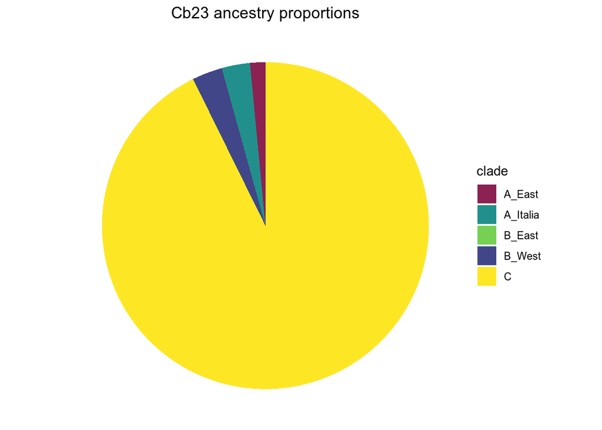

```r
Bdis_plot
```